# Notebook

[Sebastian Raschka](http://sebastianraschka.com)  
last updated: 05/29/2014

- [Open in IPython nbviewer](http://nbviewer.ipython.org/github/rasbt/One-Python-benchmark-per-day/blob/master/ipython_nbs/day9_string_endswith.ipynb?create=1)
- [Link to this IPython notebook on Github](https://github.com/rasbt/One-Python-benchmark-per-day/blob/master/ipython_nbs/day9_string_endswith.ipynb)
- [Link to the GitHub Repository One-Python-benchmark-per-day](https://github.com/rasbt/One-Python-benchmark-per-day)

I would be happy to hear your comments and suggestions.  
Please feel free to drop me a note via [twitter](https://twitter.com/rasbt), , or [google+](https://plus.google.com/118404394130788869227).

# Day 9 - One Python Benchmark per Day

## The most Pythonic way to check if a string ends with a particular substring

**-> skip to the results**

This benchmark was inspired by the article ["A Nice Little Bit of Python"](http://www.jeffknupp.com/blog/2014/05/28/a-nice-little-bit-of-python) for finding the most elegant way to determine if a string ends with a particular substring.  
There is the "old-fashioned" way using a sequence of "`or`"s, e.g.,

```
if needle.endswith('ly') or needle.endswith('ed') or\
    needle.endswith('ing') or needle.endswith('ers'):
    print('Is valid')
else:
    print('Invalid')
```

Or the more elegant way using a list comprehension that was suggested by the author:

```
if any([needle.endswith(e) for e in ('ly', 'ed', 'ing', 'ers')]):
    print('Is valid')
else:
    print('Invalid')
```

However, there are two even better solutions. One would be replacing the list comprehension by a generator, and my favorite one: feeding a tuple to the `.endswith()` method. See the different implementations below:

## Functions for checking if a string ends with a substring

```python
from re import search as re_search
from re import compile as re_compile

def old_fashioned(needle):
    return bool(needle.endswith('ly') or needle.endswith('ed') or\
        needle.endswith('ing') or needle.endswith('ers'))

def list_comprehension(needle):
    return bool(any([needle.endswith(e) for e in ('ly', 'ed', 'ing', 'ers')]))

def generator(needle):
    return bool(any(needle.endswith(e) for e in ('ly', 'ed', 'ing', 'ers')))

def endswith_tuple(needle):
    return bool(needle.endswith(('ly', 'ed', 'ing', 'ers')))

def regexpr(needle):
     return bool(re_search(r'(?:ly|ed|ing|ers)$', needle))

comp = re_compile(r'(?:ly|ed|ing|ers)$')
def compiled_regexpr(needle):
    return bool(comp.search(needle))

def map_func(needle):
    return any(map(needle.endswith, ('ly', 'ed', 'ing', 'ers')))
```

Quick note on why I am importing `re.search` as `re_search`:  
To decrease the overhead for the lookup.

```python
import re

%timeit re_search(r'(?:ly|ed|ing|ers)$', 'needlers')
%timeit re.search(r'(?:ly|ed|ing|ers)$', 'needlers')
```

```
1000000 loops, best of 3: 1.63 µs per loop
1000000 loops, best of 3: 1.69 µs per loop
```

### Verification that all functions work correcltly

```python
funcs = [old_fashioned, list_comprehension,
         generator, endswith_tuple,
         regexpr, compiled_regexpr,
         map_func
        ]
```

```python
for f in funcs:
    assert(f('neeeeedly') == True), f.__name__
    assert(f('neeeeedlee') == False), f.__name__
    assert(f('nelyeedlee') == False), f.__name__
print('All functions work correctly.')
```

```
All functions work correctly.
```

## Timing

```python
import timeit

test_cases = ["neeeeedly", "neeeeedlers", "neeeeedlee", ]
times_n = {f.__name__:[] for f in funcs}

for t in test_cases:
    for f in funcs:
        f = f.__name__
        times_n[f].append(min(timeit.Timer('%s(t)' %f,
                      'from __main__ import %s, t' %f)
                              .repeat(repeat=500, number=1000)))
```

```python
import platform
import multiprocessing

def print_sysinfo():

    print('\nPython version  :', platform.python_version())
    print('compiler        :', platform.python_compiler())

    print('\nsystem          :', platform.system())
    print('release         :', platform.release())
    print('machine         :', platform.machine())
    print('processor       :', platform.processor())
    print('CPU count       :', multiprocessing.cpu_count())
    print('interpreter     :', platform.architecture()[0])
    print('\n\n')
```

```python
%matplotlib inline
```

```python
from numpy import arange
import matplotlib.pyplot as plt

def plot():

    labels = [('old_fashioned','needle.endswith("ly") or needle.endswith("ed") or ...'),
          ('list_comprehension', 'any([needle.endswith(e) for e in ("ly", "ed", ...)])'),
          ('generator', 'any(needle.endswith(e) for e in ("ly", "ed", ...))'),
          ('regexpr', 're.search(r"(?:ly|ed|ing|ers)$", needle)'),
          ('compiled_regexpr', 'same as above, but with compiled regexpr'),
          ('map_func', 'any(map(needle.endswith, ("ly", "ed", "ing", "ers")))'),
          ('endswith_tuple', 'needle.endswith(("ly", "ed", "ing", "ers"))'),

          ]

    x_labels = ['True (first match): "neeeeedly"',
                'True (first match): "neeeeedlers"',
                'False: "neeeeedlee"'
                ]


    ind = arange(len(test_cases))  # the x locations for the groups
    width = 0.12

    fig = plt.figure(figsize=(14,8))
    ax = fig.add_subplot(111)
    colors = [(0,'c'), (1,'b'), (2,'g'), (3,'r'), (4,'y'), (5,'m'), (6, 'k')]

    for l,c in zip(labels,colors):
        ax.bar(ind + c[0]*width,
            times_n[l[0]],
            width,
            alpha=0.5,
            color=c[1],
            label=l[1]
        )

    ax.set_ylabel('execution time in microseconds', fontsize=16)
    ax.set_title('Methods for determening if a string '\
                 'ends with a particular substring',
                 fontsize=18)
    ax.set_xticks(ind + width + 0.24)
    ax.set_xticklabels(x_labels)
    leg = ax.legend(loc='upper left', bbox_to_anchor = (0.85, 1.0))
    plt.grid()
    plt.ylim([0, 0.003])
    plt.xlim([-0.2, 3.0])
    plt.show()
```

# Results

```
Python version  : 3.3.5
compiler        : GCC 4.0.1 (Apple Inc. build 5493)

system          : Darwin
release         : 13.2.0
machine         : x86_64
processor       : i386
CPU count       : 4
interpreter     : 64bit
```

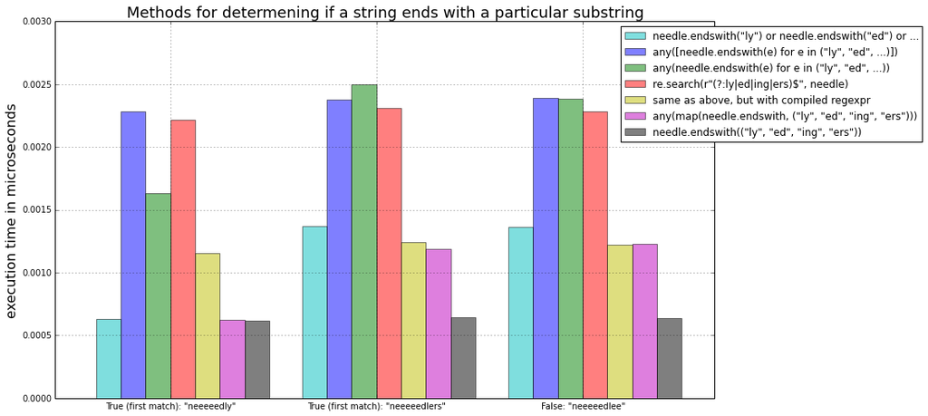

```python
print_sysinfo()
plot()
```

### Conclusion

Clearly, the most elegant and Pythonic way of determining if a string ends with a particular substring is also the most efficient one!